# Homework 1

Dylan Maddux

2023-09-06

# Question 1

In the lab, we briefly discussed the topic of magic numbers, that is, numbers that are “hard-coded” into our code rather than a more explicit statement of our intended actions. Magic numbers make our code less robust to accidents or changes, potentially introducing errors as we iteratively change parts of our analysis.

The code below contains several instances of magic numbers:

```r
x <- c(1,2,3, "four", 5, "six", 7, 6, 2)


### START ###

x <- as.numeric(x)

# Get rid of NA values
x <- x[c(1,2,3,5,7,8,9)]

# Create a vector to add to x
y <- rep(1, length = 7)

# Create new data.frame with x, y, and x+y
df <- data.frame(x = x, y = y, z = x + y)

## Only keep values where z > 5 and x <= 7 and grab column "z"
z_new <- df[c(4,5,6), 3]


### END ###

z_new
```

```
## [1] 6 8 7
```

Copy the code from the lines between `### START ###` and `### END ###` into the block below and modify it to remove the magic numbers with the appropriate expressions. Leave a comment for each modification explaining why the change is made. The value for `z_new` should remain unchanged:

```r
x <- c(1,2,3, "four", 5, "six", 7, 6, 2)

x <- as.numeric(x)
a <- which(x>0)
x <- x[a]

l <- length(x)
y <- rep(1, length = l)
df <- data.frame(x = x, y = y, z = x + y)
print(df)
```

```
##   x y z
## 1 1 1 2
## 2 2 1 3
## 3 3 1 4
## 4 5 1 6
## 5 7 1 8
## 6 6 1 7
## 7 2 1 3
```

```r
z_old <- subset(df, z > 5 & x <= 7)
z_new <- z_old[, c(3)]
z_new
```

```
## [1] 6 8 7
```

By removing instances of magic numbers, we can be sure that the “logic” of our operations will stay the same, even if the input changes. To verify this, copy your updated code again into the block below with the new input vector `x`. Verify that the results make sense.

```r
## "new" vector x
x <- c(3, 7, "four", 2)

x <- as.numeric(x)
a <- which(x>0)
x <- x[a]

l <- length(x)
y <- rep(1, length = l)
df <- data.frame(x = x, y = y, z = x + y)
print(df)
```

```
##   x y z
## 1 3 1 4
## 2 7 1 8
## 3 2 1 3
```

```r
z_old <- subset(df, z > 5 & x <= 7)
z_new <- z_old[, c(3)]

z_new
```

```
## [1] 8
```

$~$

# Question 2

The data at the URL below contains information from the Ames Assessor’s Office used in computing assessed values for individual residential properties sold in Ames, IA from 2006 to 2010. A detailed description of each of the variables can be found [here](https://jse.amstat.org/v19n3/decock/DataDocumentation.txt).

https://remiller1450.github.io/data/AmesHousing.csv

## Part A

Read this data into R and store it in a data frame named `housing`. Check the class of the variable `MS.SubClass` and compare it with the description given in the link above. Based on your assessment, should this variable be coerced to a different type? Briefly explain

```r
housing <- read.csv("https://remiller1450.github.io/data/AmesHousing.csv")
class(housing$MS.SubClass)
```

```
## [1] "integer"
```

The variable could be coerced into a character vector since the numbers identify different types of homes that were sold, and could more easily be described with words.

## Part B

Find the total number of homes in this data set with missing values for the variable `Garage.Type`

```r
sum(is.na(housing$Garage.Type))
```

```
## [1] 157
```

## Part C

Create a subset of the data set containing homes that are not missing a value for `Garage.Type`. What is the mean value of the variable `Garage.Area` for these homes?

```r
subg <- subset(housing, !is.na(housing$Garage.Type))
mean(subg$Garage.Area, na.rm = TRUE)
```

```
## [1] 499.5992
```

## Part D

Using the variable `Exter.Cond` (exterior condition) and the full housing dataset (from Part A), create a factor ordered from “Poor” condition (`Po`) to “Excellent” condition (`Ex`) following the order given in the detailed description for this variable. Use `barplot()` and `table()` to construct a bar chart showing how many homes are in each category

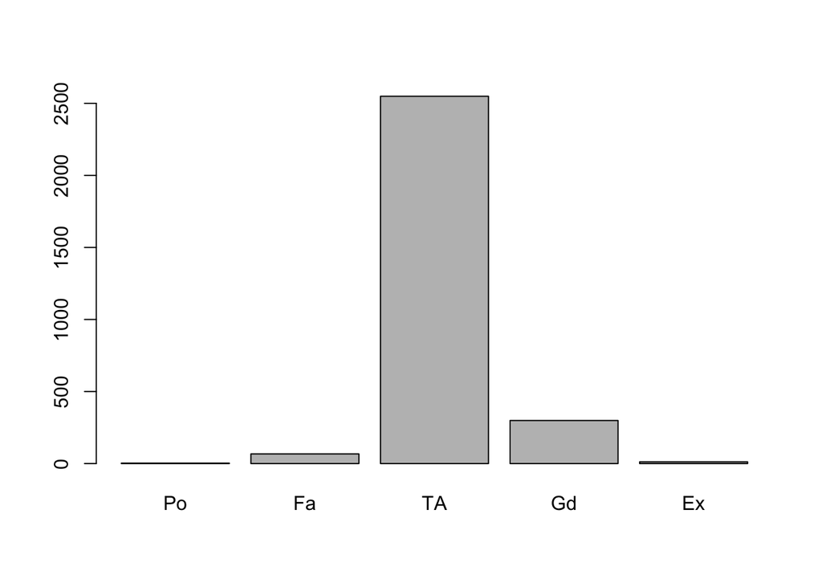

```r
exter.cond_levels <- c("Po", "Fa", "TA", "Gd", "Ex")
exter.cond <- factor(housing$Exter.Cond, levels = exter.cond_levels)
barplot(table(exter.cond))
```

```r
table(exter.cond)
```

```
## exter.cond
##   Po   Fa   TA   Gd   Ex
##    3   67 2549  299   12
```

$~$

# Question 3

The Washington Post maintains a database of fatal shootings by police officers in the line of duty. Details on their methodology can be found [here](https://github.com/washingtonpost/data-police-shootings).

The URL below contains data for all individuals entered into the database between 2015 and 2019

https://remiller1450.github.io/data/Police2019.csv

## Part A

Write code that reads data from the given url and stores it as a data.frame named `police`. Find the average age of individuals in the data set, removing missing values as necessary

```r
police <- read.csv("https://remiller1450.github.io/data/Police2019.csv")
mean(police$age, na.rm = TRUE)
```

```
## [1] 37.12151
```

## Part B

Included in this data is an indicator for state. Report the five states with the largest number of fatal shootings by police. Using magic numbers is OK here. (Hint: `?sort`).

```r
tabp <- table(police$state)
tabp2 <- sort(tabp, decreasing = TRUE)
tabp2[1:5]
```

```
##
##  CA  TX  FL  AZ  CO
## 825 496 369 259 204
```

## Part C

To important variables to consider when analyzing police shootings are whether or not the suspect was fleeing and if they were considered a threat, contained in the variables `flee` and `threat_level`, respectively. In this final part, we are going to investigate the relationship between these two variables. We will do so by taking the following steps:

1. To simplify our analysis (and because the number of observations for this is so small), begin by creating a subset of the `police` data called `police2` where we *remove* all observations where `threat_level` is equal to “undetermined”.
2. Next, use the `table()` function to create a table from `police2` where the first variable is `threat_level` and the second variable is a logical vector indicating if `flee` is equal to “Not fleeing” or not. Assign this table to the variable `tab`
3. Using the `prop.table()` function, first investigate by setting the argument `margin = 1`, so that the proportions are computed by row. Assuming that the subject was *not* fleeing, does it appear as if the threat level changed the probability of a fatal shooting? Now investigate with `margin = 2` so that the proportions are computed by column. Assuming that the threat level of the subject was “attack”, does it appear as if the subject fleeing or not changed the probability of a fatal shooting? Based on this, how would you describe the relationship between the `flee` and `threat_level` variables?

```r
police2 <- subset(police, police$threat_level != "undetermined")
tab <- table(police2$threat_level, police2$flee == "Not fleeing")
colnames(tab) <- c("Fleeing", "Not Fleeing")
tab
```

```
##
##          Fleeing Not Fleeing
##   attack    1321        2289
##   other      629        1093
```

1. When the subject is not fleeing, It doesn’t appear as if the threat level changed the probability of a fatal shooting, as the percentages are similar for both threat levels. prop.table(tab, margin = 2)
2. When the threat level of the subject is “attack,” it doesn’t appear as if the subject fleeing or not changes the probability of a fatal shooting.
3. The interaction between the “flee” and “threat_level” variables does not change the probability of fatal shootings, as the probabilities only differ within the respective variables, not across variables. Not fleeing leads to more fatal shootings for both threat levels, while the threat level “attack” leads to more fatal shootings than the other threat levels whether people flee or not.

```r
prop.table(tab, margin = 1)
```

```
##
##            Fleeing Not Fleeing
##   attack 0.3659280   0.6340720
##   other  0.3652729   0.6347271
```

```r
prop.table(tab, margin = 2)
```

```
##
##            Fleeing Not Fleeing
##   attack 0.6774359   0.6768185
##   other  0.3225641   0.3231815
```